# Risk Factor Analysis

## Outcome Variable

**Outcome Variable:** sstunted

## Predictor Variables

**Intervention Variable:** hhwealth_quart

**Adjustment Set:**

unadjusted

## Stratifying Variables

The analysis was stratified on these variable(s):

- agecat
- studyid
- country

## Data Summary

| agecat | studyid | country | A | n | nA | nAY0 | nAY1 |
| --- | --- | --- | --- | --- | --- | --- | --- |
| Birth | ki0047075b-MAL-ED | BANGLADESH | Wealth Q4 | 82 | 26 | 26 | 0 |
| Birth | ki0047075b-MAL-ED | BANGLADESH | Wealth Q1 | 82 | 4 | 4 | 0 |
| Birth | ki0047075b-MAL-ED | BANGLADESH | Wealth Q2 | 82 | 15 | 13 | 2 |
| Birth | ki0047075b-MAL-ED | BANGLADESH | Wealth Q3 | 82 | 37 | 35 | 2 |
| Birth | ki0047075b-MAL-ED | BRAZIL | Wealth Q4 | 3 | 2 | 2 | 0 |
| Birth | ki0047075b-MAL-ED | BRAZIL | Wealth Q1 | 3 | 0 | 0 | 0 |
| Birth | ki0047075b-MAL-ED | BRAZIL | Wealth Q2 | 3 | 1 | 1 | 0 |
| Birth | ki0047075b-MAL-ED | BRAZIL | Wealth Q3 | 3 | 0 | 0 | 0 |
| Birth | ki0047075b-MAL-ED | INDIA | Wealth Q4 | 55 | 21 | 19 | 2 |
| Birth | ki0047075b-MAL-ED | INDIA | Wealth Q1 | 55 | 1 | 1 | 0 |
| Birth | ki0047075b-MAL-ED | INDIA | Wealth Q2 | 55 | 9 | 9 | 0 |
| Birth | ki0047075b-MAL-ED | INDIA | Wealth Q3 | 55 | 24 | 23 | 1 |
| Birth | ki0047075b-MAL-ED | NEPAL | Wealth Q4 | 31 | 14 | 13 | 1 |
| Birth | ki0047075b-MAL-ED | NEPAL | Wealth Q1 | 31 | 11 | 11 | 0 |
| Birth | ki0047075b-MAL-ED | NEPAL | Wealth Q2 | 31 | 4 | 4 | 0 |
| Birth | ki0047075b-MAL-ED | NEPAL | Wealth Q3 | 31 | 2 | 2 | 0 |
| Birth | ki0047075b-MAL-ED | PERU | Wealth Q4 | 36 | 1 | 1 | 0 |
| Birth | ki0047075b-MAL-ED | PERU | Wealth Q1 | 36 | 23 | 23 | 0 |
| Birth | ki0047075b-MAL-ED | PERU | Wealth Q2 | 36 | 11 | 11 | 0 |
| Birth | ki0047075b-MAL-ED | PERU | Wealth Q3 | 36 | 1 | 1 | 0 |
| Birth | ki0047075b-MAL-ED | SOUTH AFRICA | Wealth Q4 | 61 | 12 | 12 | 0 |
| Birth | ki0047075b-MAL-ED | SOUTH AFRICA | Wealth Q1 | 61 | 10 | 10 | 0 |
| Birth | ki0047075b-MAL-ED | SOUTH AFRICA | Wealth Q2 | 61 | 22 | 22 | 0 |
| Birth | ki0047075b-MAL-ED | SOUTH AFRICA | Wealth Q3 | 61 | 17 | 17 | 0 |
| Birth | ki0047075b-MAL-ED | TANZANIA, UNITED REPUBLIC OF | Wealth Q4 | 23 | 0 | 0 | 0 |
| Birth | ki0047075b-MAL-ED | TANZANIA, UNITED REPUBLIC OF | Wealth Q1 | 23 | 16 | 16 | 0 |
| Birth | ki0047075b-MAL-ED | TANZANIA, UNITED REPUBLIC OF | Wealth Q2 | 23 | 7 | 7 | 0 |
| Birth | ki0047075b-MAL-ED | TANZANIA, UNITED REPUBLIC OF | Wealth Q3 | 23 | 0 | 0 | 0 |
| Birth | ki1000108-CMC-V-BCS-2002 | INDIA | Wealth Q4 | 90 | 31 | 31 | 0 |
| Birth | ki1000108-CMC-V-BCS-2002 | INDIA | Wealth Q1 | 90 | 14 | 14 | 0 |

[output cut: 446 more lines]

The following strata were considered:

- agecat: 12 months, studyid: ki0047075b-MAL-ED, country: BANGLADESH
- agecat: 12 months, studyid: ki0047075b-MAL-ED, country: BRAZIL
- agecat: 12 months, studyid: ki0047075b-MAL-ED, country: INDIA
- agecat: 12 months, studyid: ki0047075b-MAL-ED, country: NEPAL
- agecat: 12 months, studyid: ki0047075b-MAL-ED, country: PERU
- agecat: 12 months, studyid: ki0047075b-MAL-ED, country: SOUTH AFRICA
- agecat: 12 months, studyid: ki0047075b-MAL-ED, country: TANZANIA, UNITED REPUBLIC OF
- agecat: 12 months, studyid: ki1000108-CMC-V-BCS-2002, country: INDIA
- agecat: 12 months, studyid: ki1000108-IRC, country: INDIA
- agecat: 12 months, studyid: ki1017093b-PROVIDE, country: BANGLADESH
- agecat: 12 months, studyid: ki1066203-TanzaniaChild2, country: TANZANIA, UNITED REPUBLIC OF
- agecat: 12 months, studyid: ki1113344-GMS-Nepal, country: NEPAL
- agecat: 12 months, studyid: ki1114097-CONTENT, country: PERU
- agecat: 12 months, studyid: ki1135781-COHORTS, country: GUATEMALA
- agecat: 12 months, studyid: ki1135781-COHORTS, country: PHILIPPINES
- agecat: 12 months, studyid: ki1148112-LCNI-5, country: MALAWI
- agecat: 12 months, studyid: kiGH5241-JiVitA-3, country: BANGLADESH
- agecat: 12 months, studyid: kiGH5241-JiVitA-4, country: BANGLADESH
- agecat: 18 months, studyid: ki0047075b-MAL-ED, country: BANGLADESH
- agecat: 18 months, studyid: ki0047075b-MAL-ED, country: BRAZIL
- agecat: 18 months, studyid: ki0047075b-MAL-ED, country: INDIA
- agecat: 18 months, studyid: ki0047075b-MAL-ED, country: NEPAL
- agecat: 18 months, studyid: ki0047075b-MAL-ED, country: PERU
- agecat: 18 months, studyid: ki0047075b-MAL-ED, country: SOUTH AFRICA
- agecat: 18 months, studyid: ki0047075b-MAL-ED, country: TANZANIA, UNITED REPUBLIC OF
- agecat: 18 months, studyid: ki1000108-CMC-V-BCS-2002, country: INDIA
- agecat: 18 months, studyid: ki1000108-IRC, country: INDIA
- agecat: 18 months, studyid: ki1017093b-PROVIDE, country: BANGLADESH
- agecat: 18 months, studyid: ki1066203-TanzaniaChild2, country: TANZANIA, UNITED REPUBLIC OF
- agecat: 18 months, studyid: ki1113344-GMS-Nepal, country: NEPAL
- agecat: 18 months, studyid: ki1114097-CONTENT, country: PERU
- agecat: 18 months, studyid: ki1135781-COHORTS, country: GUATEMALA
- agecat: 18 months, studyid: ki1135781-COHORTS, country: PHILIPPINES
- agecat: 18 months, studyid: ki1148112-LCNI-5, country: MALAWI
- agecat: 18 months, studyid: kiGH5241-JiVitA-4, country: BANGLADESH
- agecat: 24 months, studyid: ki0047075b-MAL-ED, country: BANGLADESH
- agecat: 24 months, studyid: ki0047075b-MAL-ED, country: BRAZIL
- agecat: 24 months, studyid: ki0047075b-MAL-ED, country: INDIA
- agecat: 24 months, studyid: ki0047075b-MAL-ED, country: NEPAL
- agecat: 24 months, studyid: ki0047075b-MAL-ED, country: PERU
- agecat: 24 months, studyid: ki0047075b-MAL-ED, country: SOUTH AFRICA
- agecat: 24 months, studyid: ki0047075b-MAL-ED, country: TANZANIA, UNITED REPUBLIC OF
- agecat: 24 months, studyid: ki1000108-CMC-V-BCS-2002, country: INDIA
- agecat: 24 months, studyid: ki1000108-IRC, country: INDIA
- agecat: 24 months, studyid: ki1017093b-PROVIDE, country: BANGLADESH
- agecat: 24 months, studyid: ki1066203-TanzaniaChild2, country: TANZANIA, UNITED REPUBLIC OF
- agecat: 24 months, studyid: ki1113344-GMS-Nepal, country: NEPAL
- agecat: 24 months, studyid: ki1114097-CONTENT, country: PERU
- agecat: 24 months, studyid: ki1135781-COHORTS, country: GUATEMALA
- agecat: 24 months, studyid: ki1135781-COHORTS, country: PHILIPPINES
- agecat: 24 months, studyid: ki1148112-LCNI-5, country: MALAWI
- agecat: 24 months, studyid: kiGH5241-JiVitA-3, country: BANGLADESH
- agecat: 24 months, studyid: kiGH5241-JiVitA-4, country: BANGLADESH
- agecat: 3 months, studyid: ki0047075b-MAL-ED, country: BANGLADESH
- agecat: 3 months, studyid: ki0047075b-MAL-ED, country: BRAZIL
- agecat: 3 months, studyid: ki0047075b-MAL-ED, country: INDIA
- agecat: 3 months, studyid: ki0047075b-MAL-ED, country: NEPAL
- agecat: 3 months, studyid: ki0047075b-MAL-ED, country: PERU
- agecat: 3 months, studyid: ki0047075b-MAL-ED, country: SOUTH AFRICA
- agecat: 3 months, studyid: ki0047075b-MAL-ED, country: TANZANIA, UNITED REPUBLIC OF
- agecat: 3 months, studyid: ki1000108-CMC-V-BCS-2002, country: INDIA
- agecat: 3 months, studyid: ki1000108-IRC, country: INDIA
- agecat: 3 months, studyid: ki1017093b-PROVIDE, country: BANGLADESH
- agecat: 3 months, studyid: ki1066203-TanzaniaChild2, country: TANZANIA, UNITED REPUBLIC OF
- agecat: 3 months, studyid: ki1113344-GMS-Nepal, country: NEPAL
- agecat: 3 months, studyid: ki1114097-CONTENT, country: PERU
- agecat: 3 months, studyid: ki1135781-COHORTS, country: GUATEMALA
- agecat: 3 months, studyid: ki1135781-COHORTS, country: PHILIPPINES
- agecat: 3 months, studyid: kiGH5241-JiVitA-3, country: BANGLADESH
- agecat: 3 months, studyid: kiGH5241-JiVitA-4, country: BANGLADESH
- agecat: 6 months, studyid: ki0047075b-MAL-ED, country: BANGLADESH
- agecat: 6 months, studyid: ki0047075b-MAL-ED, country: BRAZIL
- agecat: 6 months, studyid: ki0047075b-MAL-ED, country: INDIA
- agecat: 6 months, studyid: ki0047075b-MAL-ED, country: NEPAL
- agecat: 6 months, studyid: ki0047075b-MAL-ED, country: PERU
- agecat: 6 months, studyid: ki0047075b-MAL-ED, country: SOUTH AFRICA
- agecat: 6 months, studyid: ki0047075b-MAL-ED, country: TANZANIA, UNITED REPUBLIC OF
- agecat: 6 months, studyid: ki1000108-CMC-V-BCS-2002, country: INDIA
- agecat: 6 months, studyid: ki1000108-IRC, country: INDIA
- agecat: 6 months, studyid: ki1017093b-PROVIDE, country: BANGLADESH
- agecat: 6 months, studyid: ki1066203-TanzaniaChild2, country: TANZANIA, UNITED REPUBLIC OF
- agecat: 6 months, studyid: ki1113344-GMS-Nepal, country: NEPAL
- agecat: 6 months, studyid: ki1114097-CONTENT, country: PERU
- agecat: 6 months, studyid: ki1135781-COHORTS, country: GUATEMALA
- agecat: 6 months, studyid: ki1135781-COHORTS, country: PHILIPPINES
- agecat: 6 months, studyid: ki1148112-LCNI-5, country: MALAWI
- agecat: 6 months, studyid: kiGH5241-JiVitA-3, country: BANGLADESH
- agecat: 6 months, studyid: kiGH5241-JiVitA-4, country: BANGLADESH
- agecat: 9 months, studyid: ki0047075b-MAL-ED, country: BANGLADESH
- agecat: 9 months, studyid: ki0047075b-MAL-ED, country: BRAZIL
- agecat: 9 months, studyid: ki0047075b-MAL-ED, country: INDIA
- agecat: 9 months, studyid: ki0047075b-MAL-ED, country: NEPAL
- agecat: 9 months, studyid: ki0047075b-MAL-ED, country: PERU
- agecat: 9 months, studyid: ki0047075b-MAL-ED, country: SOUTH AFRICA
- agecat: 9 months, studyid: ki0047075b-MAL-ED, country: TANZANIA, UNITED REPUBLIC OF
- agecat: 9 months, studyid: ki1000108-CMC-V-BCS-2002, country: INDIA
- agecat: 9 months, studyid: ki1000108-IRC, country: INDIA
- agecat: 9 months, studyid: ki1017093b-PROVIDE, country: BANGLADESH
- agecat: 9 months, studyid: ki1066203-TanzaniaChild2, country: TANZANIA, UNITED REPUBLIC OF
- agecat: 9 months, studyid: ki1113344-GMS-Nepal, country: NEPAL
- agecat: 9 months, studyid: ki1114097-CONTENT, country: PERU
- agecat: 9 months, studyid: ki1135781-COHORTS, country: GUATEMALA
- agecat: 9 months, studyid: ki1135781-COHORTS, country: PHILIPPINES
- agecat: 9 months, studyid: ki1148112-LCNI-5, country: MALAWI
- agecat: 9 months, studyid: kiGH5241-JiVitA-4, country: BANGLADESH
- agecat: Birth, studyid: ki0047075b-MAL-ED, country: BANGLADESH
- agecat: Birth, studyid: ki0047075b-MAL-ED, country: BRAZIL
- agecat: Birth, studyid: ki0047075b-MAL-ED, country: INDIA
- agecat: Birth, studyid: ki0047075b-MAL-ED, country: NEPAL
- agecat: Birth, studyid: ki0047075b-MAL-ED, country: PERU
- agecat: Birth, studyid: ki0047075b-MAL-ED, country: SOUTH AFRICA
- agecat: Birth, studyid: ki0047075b-MAL-ED, country: TANZANIA, UNITED REPUBLIC OF
- agecat: Birth, studyid: ki1000108-CMC-V-BCS-2002, country: INDIA
- agecat: Birth, studyid: ki1000108-IRC, country: INDIA
- agecat: Birth, studyid: ki1114097-CONTENT, country: PERU
- agecat: Birth, studyid: ki1135781-COHORTS, country: GUATEMALA
- agecat: Birth, studyid: ki1135781-COHORTS, country: PHILIPPINES
- agecat: Birth, studyid: kiGH5241-JiVitA-3, country: BANGLADESH
- agecat: Birth, studyid: kiGH5241-JiVitA-4, country: BANGLADESH

### Dropped Strata

Some strata were dropped due to rare outcomes:

- agecat: Birth, studyid: ki0047075b-MAL-ED, country: BANGLADESH
- agecat: Birth, studyid: ki0047075b-MAL-ED, country: BRAZIL
- agecat: Birth, studyid: ki0047075b-MAL-ED, country: INDIA
- agecat: Birth, studyid: ki0047075b-MAL-ED, country: NEPAL
- agecat: Birth, studyid: ki0047075b-MAL-ED, country: PERU
- agecat: Birth, studyid: ki0047075b-MAL-ED, country: SOUTH AFRICA
- agecat: Birth, studyid: ki0047075b-MAL-ED, country: TANZANIA, UNITED REPUBLIC OF
- agecat: Birth, studyid: ki1000108-CMC-V-BCS-2002, country: INDIA
- agecat: Birth, studyid: ki1000108-IRC, country: INDIA
- agecat: Birth, studyid: ki1114097-CONTENT, country: PERU
- agecat: Birth, studyid: ki1135781-COHORTS, country: GUATEMALA
- agecat: Birth, studyid: kiGH5241-JiVitA-4, country: BANGLADESH
- agecat: 3 months, studyid: ki0047075b-MAL-ED, country: BANGLADESH
- agecat: 3 months, studyid: ki0047075b-MAL-ED, country: BRAZIL
- agecat: 3 months, studyid: ki0047075b-MAL-ED, country: INDIA
- agecat: 3 months, studyid: ki0047075b-MAL-ED, country: NEPAL
- agecat: 3 months, studyid: ki0047075b-MAL-ED, country: PERU
- agecat: 3 months, studyid: ki0047075b-MAL-ED, country: SOUTH AFRICA
- agecat: 3 months, studyid: ki0047075b-MAL-ED, country: TANZANIA, UNITED REPUBLIC OF
- agecat: 3 months, studyid: ki1017093b-PROVIDE, country: BANGLADESH
- agecat: 3 months, studyid: ki1066203-TanzaniaChild2, country: TANZANIA, UNITED REPUBLIC OF
- agecat: 3 months, studyid: ki1113344-GMS-Nepal, country: NEPAL
- agecat: 3 months, studyid: ki1114097-CONTENT, country: PERU
- agecat: 6 months, studyid: ki0047075b-MAL-ED, country: BANGLADESH
- agecat: 6 months, studyid: ki0047075b-MAL-ED, country: BRAZIL
- agecat: 6 months, studyid: ki0047075b-MAL-ED, country: INDIA
- agecat: 6 months, studyid: ki0047075b-MAL-ED, country: NEPAL
- agecat: 6 months, studyid: ki0047075b-MAL-ED, country: PERU
- agecat: 6 months, studyid: ki0047075b-MAL-ED, country: SOUTH AFRICA
- agecat: 6 months, studyid: ki0047075b-MAL-ED, country: TANZANIA, UNITED REPUBLIC OF
- agecat: 6 months, studyid: ki1000108-CMC-V-BCS-2002, country: INDIA
- agecat: 6 months, studyid: ki1000108-IRC, country: INDIA
- agecat: 6 months, studyid: ki1017093b-PROVIDE, country: BANGLADESH
- agecat: 6 months, studyid: ki1066203-TanzaniaChild2, country: TANZANIA, UNITED REPUBLIC OF
- agecat: 6 months, studyid: ki1113344-GMS-Nepal, country: NEPAL
- agecat: 6 months, studyid: ki1114097-CONTENT, country: PERU
- agecat: 9 months, studyid: ki0047075b-MAL-ED, country: BANGLADESH
- agecat: 9 months, studyid: ki0047075b-MAL-ED, country: BRAZIL
- agecat: 9 months, studyid: ki0047075b-MAL-ED, country: INDIA
- agecat: 9 months, studyid: ki0047075b-MAL-ED, country: NEPAL
- agecat: 9 months, studyid: ki0047075b-MAL-ED, country: PERU
- agecat: 9 months, studyid: ki0047075b-MAL-ED, country: SOUTH AFRICA
- agecat: 9 months, studyid: ki0047075b-MAL-ED, country: TANZANIA, UNITED REPUBLIC OF
- agecat: 9 months, studyid: ki1000108-CMC-V-BCS-2002, country: INDIA
- agecat: 9 months, studyid: ki1017093b-PROVIDE, country: BANGLADESH
- agecat: 9 months, studyid: ki1066203-TanzaniaChild2, country: TANZANIA, UNITED REPUBLIC OF
- agecat: 9 months, studyid: ki1114097-CONTENT, country: PERU
- agecat: 12 months, studyid: ki0047075b-MAL-ED, country: BANGLADESH
- agecat: 12 months, studyid: ki0047075b-MAL-ED, country: BRAZIL
- agecat: 12 months, studyid: ki0047075b-MAL-ED, country: INDIA
- agecat: 12 months, studyid: ki0047075b-MAL-ED, country: NEPAL
- agecat: 12 months, studyid: ki0047075b-MAL-ED, country: PERU
- agecat: 12 months, studyid: ki0047075b-MAL-ED, country: SOUTH AFRICA
- agecat: 12 months, studyid: ki0047075b-MAL-ED, country: TANZANIA, UNITED REPUBLIC OF
- agecat: 12 months, studyid: ki1017093b-PROVIDE, country: BANGLADESH
- agecat: 12 months, studyid: ki1066203-TanzaniaChild2, country: TANZANIA, UNITED REPUBLIC OF
- agecat: 12 months, studyid: ki1114097-CONTENT, country: PERU
- agecat: 18 months, studyid: ki0047075b-MAL-ED, country: BANGLADESH
- agecat: 18 months, studyid: ki0047075b-MAL-ED, country: BRAZIL
- agecat: 18 months, studyid: ki0047075b-MAL-ED, country: INDIA
- agecat: 18 months, studyid: ki0047075b-MAL-ED, country: NEPAL
- agecat: 18 months, studyid: ki0047075b-MAL-ED, country: PERU
- agecat: 18 months, studyid: ki0047075b-MAL-ED, country: SOUTH AFRICA
- agecat: 18 months, studyid: ki0047075b-MAL-ED, country: TANZANIA, UNITED REPUBLIC OF
- agecat: 18 months, studyid: ki1114097-CONTENT, country: PERU
- agecat: 24 months, studyid: ki0047075b-MAL-ED, country: BANGLADESH
- agecat: 24 months, studyid: ki0047075b-MAL-ED, country: BRAZIL
- agecat: 24 months, studyid: ki0047075b-MAL-ED, country: INDIA
- agecat: 24 months, studyid: ki0047075b-MAL-ED, country: NEPAL
- agecat: 24 months, studyid: ki0047075b-MAL-ED, country: PERU
- agecat: 24 months, studyid: ki0047075b-MAL-ED, country: SOUTH AFRICA
- agecat: 24 months, studyid: ki0047075b-MAL-ED, country: TANZANIA, UNITED REPUBLIC OF
- agecat: 24 months, studyid: ki1066203-TanzaniaChild2, country: TANZANIA, UNITED REPUBLIC OF
- agecat: 24 months, studyid: ki1114097-CONTENT, country: PERU

## Methods Detail

We’re interested in the causal parameters $E[Y_a]$ for all values of $a \in \mathcal{A}$. These parameters represent the mean outcome if, possibly contrary to fact, we intervened to set all units to have $A=a$. Under the randomization and positivity assumptions, these are identified by the statistical parameters $\psi_a=E_W[E_{Y|A,W}(Y|A=a,W)]$. In addition, we’re interested in the mean of $Y$, $E[Y]$ under no intervention (the observed mean). We will estimate these parameters by using SuperLearner to fit the relevant likelihood factors – $E_{Y|A,W}(Y|A=a,W)$ and $p(A=a|W)$, and then updating our likelihood fit using a joint TMLE.

For unadjusted analyses ($W=\{\}$), initial likelihoods were estimated using Lrnr_glm to estimate the simple $E(Y|A)$ and Lrnr_mean to estimate $p(A)$. For adjusted analyses, a small library containing Lrnr_glmnet, Lrnr_xgboost, and Lrnr_mean was used.

Having estimated these parameters, we will then use the delta method to estimate relative risks and attributable risks relative to a prespecified baseline level of $A$.

# Results Detail

## Results Plots

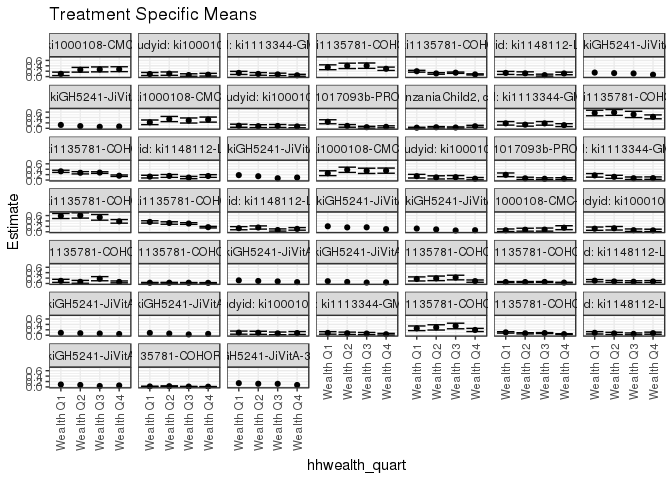

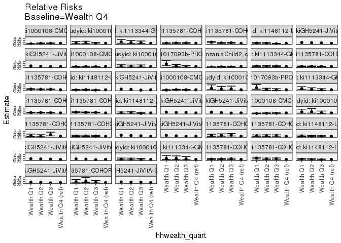

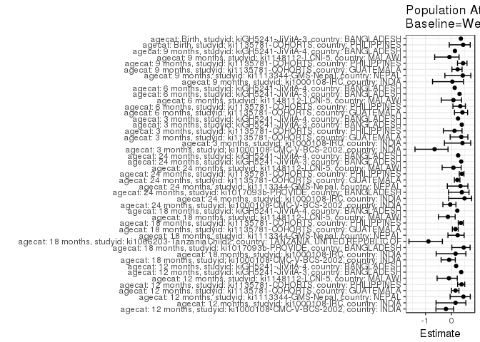

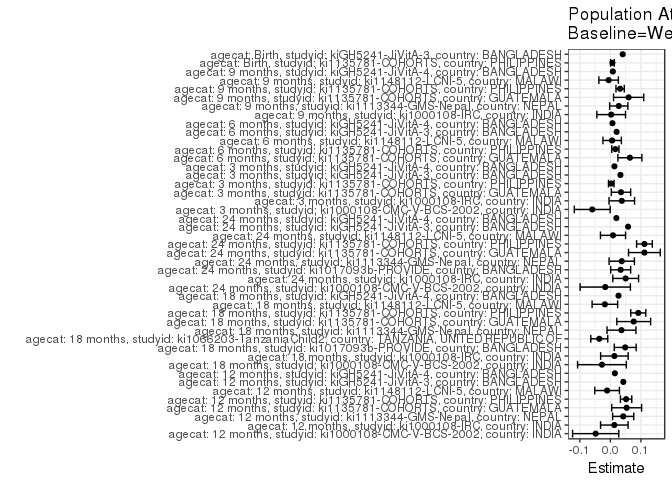

## Results Table

### Parameter: TSM

| agecat | studyid | country | intervention_level | baseline_level | estimate | ci_lower | ci_upper |
| --- | --- | --- | --- | --- | --- | --- | --- |
| Birth | ki1135781-COHORTS | PHILIPPINES | Wealth Q4 | NA | 0.0083135 | 0.0021795 | 0.0144475 |
| Birth | ki1135781-COHORTS | PHILIPPINES | Wealth Q1 | NA | 0.0174672 | 0.0076695 | 0.0272650 |
| Birth | ki1135781-COHORTS | PHILIPPINES | Wealth Q2 | NA | 0.0260223 | 0.0125676 | 0.0394771 |
| Birth | ki1135781-COHORTS | PHILIPPINES | Wealth Q3 | NA | 0.0132383 | 0.0060886 | 0.0203880 |
| Birth | kiGH5241-JiVitA-3 | BANGLADESH | Wealth Q4 | NA | 0.0720764 | NA | NA |
| Birth | kiGH5241-JiVitA-3 | BANGLADESH | Wealth Q1 | NA | 0.1390291 | NA | NA |
| Birth | kiGH5241-JiVitA-3 | BANGLADESH | Wealth Q2 | NA | 0.1171756 | NA | NA |
| Birth | kiGH5241-JiVitA-3 | BANGLADESH | Wealth Q3 | NA | 0.1145663 | NA | NA |
| 3 months | ki1000108-CMC-V-BCS-2002 | INDIA | Wealth Q4 | NA | 0.1505376 | 0.0777593 | 0.2233159 |
| 3 months | ki1000108-CMC-V-BCS-2002 | INDIA | Wealth Q1 | NA | 0.0555556 | 0.0081663 | 0.1029448 |
| 3 months | ki1000108-CMC-V-BCS-2002 | INDIA | Wealth Q2 | NA | 0.0760870 | 0.0218337 | 0.1303402 |
| 3 months | ki1000108-CMC-V-BCS-2002 | INDIA | Wealth Q3 | NA | 0.0804598 | 0.0232245 | 0.1376951 |
| 3 months | ki1000108-IRC | INDIA | Wealth Q4 | NA | 0.0510204 | 0.0074020 | 0.0946388 |
| 3 months | ki1000108-IRC | INDIA | Wealth Q1 | NA | 0.1142857 | 0.0533558 | 0.1752156 |
| 3 months | ki1000108-IRC | INDIA | Wealth Q2 | NA | 0.1287129 | 0.0633226 | 0.1941032 |
| 3 months | ki1000108-IRC | INDIA | Wealth Q3 | NA | 0.0582524 | 0.0129639 | 0.1035409 |
| 3 months | ki1135781-COHORTS | GUATEMALA | Wealth Q4 | NA | 0.0578035 | 0.0229896 | 0.0926174 |
| 3 months | ki1135781-COHORTS | GUATEMALA | Wealth Q1 | NA | 0.0970874 | 0.0398455 | 0.1543292 |
| 3 months | ki1135781-COHORTS | GUATEMALA | Wealth Q2 | NA | 0.0617284 | 0.0092607 | 0.1141961 |
| 3 months | ki1135781-COHORTS | GUATEMALA | Wealth Q3 | NA | 0.1770833 | 0.1006366 | 0.2535301 |
| 3 months | ki1135781-COHORTS | PHILIPPINES | Wealth Q4 | NA | 0.0227560 | 0.0123620 | 0.0331501 |
| 3 months | ki1135781-COHORTS | PHILIPPINES | Wealth Q1 | NA | 0.0268987 | 0.0142831 | 0.0395144 |
| 3 months | ki1135781-COHORTS | PHILIPPINES | Wealth Q2 | NA | 0.0273438 | 0.0132152 | 0.0414723 |
| 3 months | ki1135781-COHORTS | PHILIPPINES | Wealth Q3 | NA | 0.0266241 | 0.0163257 | 0.0369224 |
| 3 months | kiGH5241-JiVitA-3 | BANGLADESH | Wealth Q4 | NA | 0.0503755 | NA | NA |
| 3 months | kiGH5241-JiVitA-3 | BANGLADESH | Wealth Q1 | NA | 0.1146390 | NA | NA |
| 3 months | kiGH5241-JiVitA-3 | BANGLADESH | Wealth Q2 | NA | 0.0929932 | NA | NA |
| 3 months | kiGH5241-JiVitA-3 | BANGLADESH | Wealth Q3 | NA | 0.0774344 | NA | NA |
| 3 months | kiGH5241-JiVitA-4 | BANGLADESH | Wealth Q4 | NA | 0.0400000 | NA | NA |
| 3 months | kiGH5241-JiVitA-4 | BANGLADESH | Wealth Q1 | NA | 0.0848214 | NA | NA |

[output cut: 150 more lines]

### Parameter: E(Y)

| agecat | studyid | country | intervention_level | baseline_level | estimate | ci_lower | ci_upper |
| --- | --- | --- | --- | --- | --- | --- | --- |
| Birth | ki1135781-COHORTS | PHILIPPINES | NA | NA | 0.0150869 | 0.0107594 | 0.0194144 |
| Birth | kiGH5241-JiVitA-3 | BANGLADESH | NA | NA | 0.1125950 | NA | NA |
| 3 months | ki1000108-CMC-V-BCS-2002 | INDIA | NA | NA | 0.0911602 | 0.0614681 | 0.1208523 |
| 3 months | ki1000108-IRC | INDIA | NA | NA | 0.0884521 | 0.0608318 | 0.1160724 |
| 3 months | ki1135781-COHORTS | GUATEMALA | NA | NA | 0.0927152 | 0.0659774 | 0.1194531 |
| 3 months | ki1135781-COHORTS | PHILIPPINES | NA | NA | 0.0257481 | 0.0199566 | 0.0315396 |
| 3 months | kiGH5241-JiVitA-3 | BANGLADESH | NA | NA | 0.0833740 | NA | NA |
| 3 months | kiGH5241-JiVitA-4 | BANGLADESH | NA | NA | 0.0533333 | NA | NA |
| 6 months | ki1135781-COHORTS | GUATEMALA | NA | NA | 0.1522727 | 0.1186638 | 0.1858817 |
| 6 months | ki1135781-COHORTS | PHILIPPINES | NA | NA | 0.0487445 | 0.0406327 | 0.0568562 |
| 6 months | ki1148112-LCNI-5 | MALAWI | NA | NA | 0.0796569 | 0.0610679 | 0.0982459 |
| 6 months | kiGH5241-JiVitA-3 | BANGLADESH | NA | NA | 0.0659129 | NA | NA |
| 6 months | kiGH5241-JiVitA-4 | BANGLADESH | NA | NA | 0.0558214 | NA | NA |
| 9 months | ki1000108-IRC | INDIA | NA | NA | 0.0835381 | 0.0566237 | 0.1104525 |
| 9 months | ki1113344-GMS-Nepal | NEPAL | NA | NA | 0.0635209 | 0.0431376 | 0.0839041 |
| 9 months | ki1135781-COHORTS | GUATEMALA | NA | NA | 0.2540416 | 0.2129913 | 0.2950918 |
| 9 months | ki1135781-COHORTS | PHILIPPINES | NA | NA | 0.0722714 | 0.0625243 | 0.0820185 |
| 9 months | ki1148112-LCNI-5 | MALAWI | NA | NA | 0.0700152 | 0.0504885 | 0.0895420 |
| 9 months | kiGH5241-JiVitA-4 | BANGLADESH | NA | NA | 0.0625000 | NA | NA |
| 12 months | ki1000108-CMC-V-BCS-2002 | INDIA | NA | NA | 0.2255435 | 0.1827844 | 0.2683026 |
| 12 months | ki1000108-IRC | INDIA | NA | NA | 0.0837438 | 0.0567661 | 0.1107216 |
| 12 months | ki1113344-GMS-Nepal | NEPAL | NA | NA | 0.0913978 | 0.0674660 | 0.1153296 |
| 12 months | ki1135781-COHORTS | GUATEMALA | NA | NA | 0.3433134 | 0.3016948 | 0.3849320 |
| 12 months | ki1135781-COHORTS | PHILIPPINES | NA | NA | 0.1330754 | 0.1199794 | 0.1461715 |
| 12 months | ki1148112-LCNI-5 | MALAWI | NA | NA | 0.1062802 | 0.0820208 | 0.1305395 |
| 12 months | kiGH5241-JiVitA-3 | BANGLADESH | NA | NA | 0.1137026 | NA | NA |
| 12 months | kiGH5241-JiVitA-4 | BANGLADESH | NA | NA | 0.0830721 | NA | NA |
| 18 months | ki1000108-CMC-V-BCS-2002 | INDIA | NA | NA | 0.2953930 | 0.2487810 | 0.3420050 |
| 18 months | ki1000108-IRC | INDIA | NA | NA | 0.0839506 | 0.0569092 | 0.1109920 |
| 18 months | ki1017093b-PROVIDE | BANGLADESH | NA | NA | 0.1034483 | 0.0779966 | 0.1288999 |
| 18 months | ki1066203-TanzaniaChild2 | TANZANIA, UNITED REPUBLIC OF | NA | NA | 0.0409417 | 0.0285100 | 0.0533733 |
| 18 months | ki1113344-GMS-Nepal | NEPAL | NA | NA | 0.1545455 | 0.1243087 | 0.1847822 |
| 18 months | ki1135781-COHORTS | GUATEMALA | NA | NA | 0.5011876 | 0.4533696 | 0.5490057 |
| 18 months | ki1135781-COHORTS | PHILIPPINES | NA | NA | 0.2516051 | 0.2345645 | 0.2686458 |
| 18 months | ki1148112-LCNI-5 | MALAWI | NA | NA | 0.1307371 | 0.1060790 | 0.1553953 |
| 18 months | kiGH5241-JiVitA-4 | BANGLADESH | NA | NA | 0.1202275 | NA | NA |
| 24 months | ki1000108-CMC-V-BCS-2002 | INDIA | NA | NA | 0.3306452 | 0.2827744 | 0.3785159 |
| 24 months | ki1000108-IRC | INDIA | NA | NA | 0.1002445 | 0.0711031 | 0.1293859 |
| 24 months | ki1017093b-PROVIDE | BANGLADESH | NA | NA | 0.0850694 | 0.0622663 | 0.1078726 |
| 24 months | ki1113344-GMS-Nepal | NEPAL | NA | NA | 0.1082164 | 0.0809323 | 0.1355005 |
| 24 months | ki1135781-COHORTS | GUATEMALA | NA | NA | 0.4969819 | 0.4529802 | 0.5409836 |
| 24 months | ki1135781-COHORTS | PHILIPPINES | NA | NA | 0.2817996 | 0.2639639 | 0.2996353 |
| 24 months | ki1148112-LCNI-5 | MALAWI | NA | NA | 0.1149826 | 0.0888632 | 0.1411019 |
| 24 months | kiGH5241-JiVitA-3 | BANGLADESH | NA | NA | 0.1553172 | NA | NA |
| 24 months | kiGH5241-JiVitA-4 | BANGLADESH | NA | NA | 0.0776000 | NA | NA |

### Parameter: RR

| agecat | studyid | country | intervention_level | baseline_level | estimate | ci_lower | ci_upper |
| --- | --- | --- | --- | --- | --- | --- | --- |
| Birth | ki1135781-COHORTS | PHILIPPINES | Wealth Q4 | Wealth Q4 | 1.0000000 | 1.0000000 | 1.0000000 |
| Birth | ki1135781-COHORTS | PHILIPPINES | Wealth Q1 | Wealth Q4 | 2.1010605 | 0.8316064 | 5.3083471 |
| Birth | ki1135781-COHORTS | PHILIPPINES | Wealth Q2 | Wealth Q4 | 3.1301115 | 1.2713841 | 7.7062457 |
| Birth | ki1135781-COHORTS | PHILIPPINES | Wealth Q3 | Wealth Q4 | 1.5923771 | 0.6381739 | 3.9733128 |
| Birth | kiGH5241-JiVitA-3 | BANGLADESH | Wealth Q4 | Wealth Q4 | 1.0000000 | NA | NA |
| Birth | kiGH5241-JiVitA-3 | BANGLADESH | Wealth Q1 | Wealth Q4 | 1.9289140 | NA | NA |
| Birth | kiGH5241-JiVitA-3 | BANGLADESH | Wealth Q2 | Wealth Q4 | 1.6257141 | NA | NA |
| Birth | kiGH5241-JiVitA-3 | BANGLADESH | Wealth Q3 | Wealth Q4 | 1.5895124 | NA | NA |
| 3 months | ki1000108-CMC-V-BCS-2002 | INDIA | Wealth Q4 | Wealth Q4 | 1.0000000 | 1.0000000 | 1.0000000 |
| 3 months | ki1000108-CMC-V-BCS-2002 | INDIA | Wealth Q1 | Wealth Q4 | 0.3690476 | 0.1384407 | 0.9837871 |
| 3 months | ki1000108-CMC-V-BCS-2002 | INDIA | Wealth Q2 | Wealth Q4 | 0.5054348 | 0.2135631 | 1.1962004 |
| 3 months | ki1000108-CMC-V-BCS-2002 | INDIA | Wealth Q3 | Wealth Q4 | 0.5344828 | 0.2261528 | 1.2631807 |
| 3 months | ki1000108-IRC | INDIA | Wealth Q4 | Wealth Q4 | 1.0000000 | 1.0000000 | 1.0000000 |
| 3 months | ki1000108-IRC | INDIA | Wealth Q1 | Wealth Q4 | 2.2400000 | 0.8178653 | 6.1349952 |
| 3 months | ki1000108-IRC | INDIA | Wealth Q2 | Wealth Q4 | 2.5227723 | 0.9332154 | 6.8198400 |
| 3 months | ki1000108-IRC | INDIA | Wealth Q3 | Wealth Q4 | 1.1417476 | 0.3595144 | 3.6259676 |
| 3 months | ki1135781-COHORTS | GUATEMALA | Wealth Q4 | Wealth Q4 | 1.0000000 | 1.0000000 | 1.0000000 |
| 3 months | ki1135781-COHORTS | GUATEMALA | Wealth Q1 | Wealth Q4 | 1.6796116 | 0.7230582 | 3.9016155 |
| 3 months | ki1135781-COHORTS | GUATEMALA | Wealth Q2 | Wealth Q4 | 1.0679012 | 0.3768020 | 3.0265579 |
| 3 months | ki1135781-COHORTS | GUATEMALA | Wealth Q3 | Wealth Q4 | 3.0635417 | 1.4601728 | 6.4275186 |
| 3 months | ki1135781-COHORTS | PHILIPPINES | Wealth Q4 | Wealth Q4 | 1.0000000 | 1.0000000 | 1.0000000 |
| 3 months | ki1135781-COHORTS | PHILIPPINES | Wealth Q1 | Wealth Q4 | 1.1820499 | 0.6142072 | 2.2748710 |
| 3 months | ki1135781-COHORTS | PHILIPPINES | Wealth Q2 | Wealth Q4 | 1.2016059 | 0.6029107 | 2.3948105 |
| 3 months | ki1135781-COHORTS | PHILIPPINES | Wealth Q3 | Wealth Q4 | 1.1699799 | 0.6430368 | 2.1287317 |
| 3 months | kiGH5241-JiVitA-3 | BANGLADESH | Wealth Q4 | Wealth Q4 | 1.0000000 | NA | NA |
| 3 months | kiGH5241-JiVitA-3 | BANGLADESH | Wealth Q1 | Wealth Q4 | 2.2756917 | NA | NA |
| 3 months | kiGH5241-JiVitA-3 | BANGLADESH | Wealth Q2 | Wealth Q4 | 1.8460020 | NA | NA |
| 3 months | kiGH5241-JiVitA-3 | BANGLADESH | Wealth Q3 | Wealth Q4 | 1.5371443 | NA | NA |
| 3 months | kiGH5241-JiVitA-4 | BANGLADESH | Wealth Q4 | Wealth Q4 | 1.0000000 | NA | NA |
| 3 months | kiGH5241-JiVitA-4 | BANGLADESH | Wealth Q1 | Wealth Q4 | 2.1205357 | NA | NA |

[output cut: 150 more lines]

### Parameter: PAR

| agecat | studyid | country | intervention_level | baseline_level | estimate | ci_lower | ci_upper |
| --- | --- | --- | --- | --- | --- | --- | --- |
| Birth | ki1135781-COHORTS | PHILIPPINES | Wealth Q4 | NA | 0.0067734 | 0.0008091 | 0.0127376 |
| Birth | kiGH5241-JiVitA-3 | BANGLADESH | Wealth Q4 | NA | 0.0405187 | NA | NA |
| 3 months | ki1000108-CMC-V-BCS-2002 | INDIA | Wealth Q4 | NA | -0.0593774 | -0.1181720 | -0.0005828 |
| 3 months | ki1000108-IRC | INDIA | Wealth Q4 | NA | 0.0374317 | -0.0043920 | 0.0792554 |
| 3 months | ki1135781-COHORTS | GUATEMALA | Wealth Q4 | NA | 0.0349118 | 0.0032702 | 0.0665534 |
| 3 months | ki1135781-COHORTS | PHILIPPINES | Wealth Q4 | NA | 0.0029921 | -0.0060693 | 0.0120535 |
| 3 months | kiGH5241-JiVitA-3 | BANGLADESH | Wealth Q4 | NA | 0.0329985 | NA | NA |
| 3 months | kiGH5241-JiVitA-4 | BANGLADESH | Wealth Q4 | NA | 0.0133333 | NA | NA |
| 6 months | ki1135781-COHORTS | GUATEMALA | Wealth Q4 | NA | 0.0640374 | 0.0247479 | 0.1033269 |
| 6 months | ki1135781-COHORTS | PHILIPPINES | Wealth Q4 | NA | 0.0164430 | 0.0046635 | 0.0282224 |
| 6 months | ki1148112-LCNI-5 | MALAWI | Wealth Q4 | NA | 0.0059241 | -0.0242790 | 0.0361273 |
| 6 months | kiGH5241-JiVitA-3 | BANGLADESH | Wealth Q4 | NA | 0.0204201 | NA | NA |
| 6 months | kiGH5241-JiVitA-4 | BANGLADESH | Wealth Q4 | NA | 0.0068703 | NA | NA |
| 9 months | ki1000108-IRC | INDIA | Wealth Q4 | NA | 0.0027300 | -0.0442601 | 0.0497201 |
| 9 months | ki1113344-GMS-Nepal | NEPAL | Wealth Q4 | NA | 0.0275496 | -0.0023028 | 0.0574021 |
| 9 months | ki1135781-COHORTS | GUATEMALA | Wealth Q4 | NA | 0.0599239 | 0.0104656 | 0.1093822 |
| 9 months | ki1135781-COHORTS | PHILIPPINES | Wealth Q4 | NA | 0.0320029 | 0.0184077 | 0.0455982 |
| 9 months | ki1148112-LCNI-5 | MALAWI | Wealth Q4 | NA | -0.0056605 | -0.0375469 | 0.0262260 |
| 9 months | kiGH5241-JiVitA-4 | BANGLADESH | Wealth Q4 | NA | 0.0082627 | NA | NA |
| 12 months | ki1000108-CMC-V-BCS-2002 | INDIA | Wealth Q4 | NA | -0.0481407 | -0.1238169 | 0.0275354 |
| 12 months | ki1000108-IRC | INDIA | Wealth Q4 | NA | 0.0130368 | -0.0320990 | 0.0581725 |
| 12 months | ki1113344-GMS-Nepal | NEPAL | Wealth Q4 | NA | 0.0421021 | 0.0075130 | 0.0766912 |
| 12 months | ki1135781-COHORTS | GUATEMALA | Wealth Q4 | NA | 0.0534583 | 0.0045014 | 0.1024152 |
| 12 months | ki1135781-COHORTS | PHILIPPINES | Wealth Q4 | NA | 0.0515837 | 0.0329757 | 0.0701918 |
| 12 months | ki1148112-LCNI-5 | MALAWI | Wealth Q4 | NA | -0.0106789 | -0.0510841 | 0.0297263 |
| 12 months | kiGH5241-JiVitA-3 | BANGLADESH | Wealth Q4 | NA | 0.0424831 | NA | NA |
| 12 months | kiGH5241-JiVitA-4 | BANGLADESH | Wealth Q4 | NA | 0.0148127 | NA | NA |
| 18 months | ki1000108-CMC-V-BCS-2002 | INDIA | Wealth Q4 | NA | -0.0275237 | -0.1074033 | 0.0523559 |
| 18 months | ki1000108-IRC | INDIA | Wealth Q4 | NA | 0.0132435 | -0.0318963 | 0.0583834 |
| 18 months | ki1017093b-PROVIDE | BANGLADESH | Wealth Q4 | NA | 0.0486538 | 0.0127441 | 0.0845634 |
| 18 months | ki1066203-TanzaniaChild2 | TANZANIA, UNITED REPUBLIC OF | Wealth Q4 | NA | -0.0363116 | -0.0640583 | -0.0085649 |
| 18 months | ki1113344-GMS-Nepal | NEPAL | Wealth Q4 | NA | 0.0364899 | -0.0108366 | 0.0838164 |
| 18 months | ki1135781-COHORTS | GUATEMALA | Wealth Q4 | NA | 0.0766066 | 0.0211717 | 0.1320416 |
| 18 months | ki1135781-COHORTS | PHILIPPINES | Wealth Q4 | NA | 0.0915485 | 0.0669003 | 0.1161967 |
| 18 months | ki1148112-LCNI-5 | MALAWI | Wealth Q4 | NA | -0.0179808 | -0.0598237 | 0.0238620 |
| 18 months | kiGH5241-JiVitA-4 | BANGLADESH | Wealth Q4 | NA | 0.0267023 | NA | NA |
| 24 months | ki1000108-CMC-V-BCS-2002 | INDIA | Wealth Q4 | NA | -0.0167233 | -0.0991166 | 0.0656701 |
| 24 months | ki1000108-IRC | INDIA | Wealth Q4 | NA | 0.0502445 | 0.0080079 | 0.0924811 |
| 24 months | ki1017093b-PROVIDE | BANGLADESH | Wealth Q4 | NA | 0.0337874 | 0.0010759 | 0.0664989 |
| 24 months | ki1113344-GMS-Nepal | NEPAL | Wealth Q4 | NA | 0.0373503 | -0.0041737 | 0.0788743 |
| 24 months | ki1135781-COHORTS | GUATEMALA | Wealth Q4 | NA | 0.1116160 | 0.0595136 | 0.1637185 |
| 24 months | ki1135781-COHORTS | PHILIPPINES | Wealth Q4 | NA | 0.1117415 | 0.0859965 | 0.1374864 |
| 24 months | ki1148112-LCNI-5 | MALAWI | Wealth Q4 | NA | 0.0087326 | -0.0324119 | 0.0498771 |
| 24 months | kiGH5241-JiVitA-3 | BANGLADESH | Wealth Q4 | NA | 0.0580826 | NA | NA |
| 24 months | kiGH5241-JiVitA-4 | BANGLADESH | Wealth Q4 | NA | 0.0197769 | NA | NA |

### Parameter: PAF

| agecat | studyid | country | intervention_level | baseline_level | estimate | ci_lower | ci_upper |
| --- | --- | --- | --- | --- | --- | --- | --- |
| Birth | ki1135781-COHORTS | PHILIPPINES | Wealth Q4 | NA | 0.4489569 | -0.0865616 | 0.7205419 |
| Birth | kiGH5241-JiVitA-3 | BANGLADESH | Wealth Q4 | NA | 0.3598619 | NA | NA |
| 3 months | ki1000108-CMC-V-BCS-2002 | INDIA | Wealth Q4 | NA | -0.6513522 | -1.4055124 | -0.1336313 |
| 3 months | ki1000108-IRC | INDIA | Wealth Q4 | NA | 0.4231859 | -0.2719736 | 0.7384266 |
| 3 months | ki1135781-COHORTS | GUATEMALA | Wealth Q4 | NA | 0.3765483 | -0.0514571 | 0.6303301 |
| 3 months | ki1135781-COHORTS | PHILIPPINES | Wealth Q4 | NA | 0.1162060 | -0.3147119 | 0.4058836 |
| 3 months | kiGH5241-JiVitA-3 | BANGLADESH | Wealth Q4 | NA | 0.3957892 | NA | NA |
| 3 months | kiGH5241-JiVitA-4 | BANGLADESH | Wealth Q4 | NA | 0.2500000 | NA | NA |
| 6 months | ki1135781-COHORTS | GUATEMALA | Wealth Q4 | NA | 0.4205443 | 0.1164581 | 0.6199740 |
| 6 months | ki1135781-COHORTS | PHILIPPINES | Wealth Q4 | NA | 0.3373302 | 0.0545516 | 0.5355313 |
| 6 months | ki1148112-LCNI-5 | MALAWI | Wealth Q4 | NA | 0.0743708 | -0.3937368 | 0.3852574 |
| 6 months | kiGH5241-JiVitA-3 | BANGLADESH | Wealth Q4 | NA | 0.3098039 | NA | NA |
| 6 months | kiGH5241-JiVitA-4 | BANGLADESH | Wealth Q4 | NA | 0.1230769 | NA | NA |
| 9 months | ki1000108-IRC | INDIA | Wealth Q4 | NA | 0.0326797 | -0.7301241 | 0.4591668 |
| 9 months | ki1113344-GMS-Nepal | NEPAL | Wealth Q4 | NA | 0.4337102 | -0.2547626 | 0.7444264 |
| 9 months | ki1135781-COHORTS | GUATEMALA | Wealth Q4 | NA | 0.2358824 | 0.0164639 | 0.4063504 |
| 9 months | ki1135781-COHORTS | PHILIPPINES | Wealth Q4 | NA | 0.4428160 | 0.2313782 | 0.5960900 |
| 9 months | ki1148112-LCNI-5 | MALAWI | Wealth Q4 | NA | -0.0808461 | -0.6465275 | 0.2904897 |
| 9 months | kiGH5241-JiVitA-4 | BANGLADESH | Wealth Q4 | NA | 0.1322034 | NA | NA |
| 12 months | ki1000108-CMC-V-BCS-2002 | INDIA | Wealth Q4 | NA | -0.2134432 | -0.5990037 | 0.0791488 |
| 12 months | ki1000108-IRC | INDIA | Wealth Q4 | NA | 0.1556744 | -0.5948668 | 0.5530124 |
| 12 months | ki1113344-GMS-Nepal | NEPAL | Wealth Q4 | NA | 0.4606462 | -0.0531196 | 0.7237707 |
| 12 months | ki1135781-COHORTS | GUATEMALA | Wealth Q4 | NA | 0.1557128 | 0.0005349 | 0.2867977 |
| 12 months | ki1135781-COHORTS | PHILIPPINES | Wealth Q4 | NA | 0.3876277 | 0.2359172 | 0.5092157 |
| 12 months | ki1148112-LCNI-5 | MALAWI | Wealth Q4 | NA | -0.1004785 | -0.5538646 | 0.2206188 |
| 12 months | kiGH5241-JiVitA-3 | BANGLADESH | Wealth Q4 | NA | 0.3736335 | NA | NA |
| 12 months | kiGH5241-JiVitA-4 | BANGLADESH | Wealth Q4 | NA | 0.1783115 | NA | NA |
| 18 months | ki1000108-CMC-V-BCS-2002 | INDIA | Wealth Q4 | NA | -0.0931766 | -0.3999357 | 0.1463643 |
| 18 months | ki1000108-IRC | INDIA | Wealth Q4 | NA | 0.1577540 | -0.5909124 | 0.5541060 |
| 18 months | ki1017093b-PROVIDE | BANGLADESH | Wealth Q4 | NA | 0.4703196 | 0.0128279 | 0.7157929 |
| 18 months | ki1066203-TanzaniaChild2 | TANZANIA, UNITED REPUBLIC OF | Wealth Q4 | NA | -0.8869099 | -1.6365541 | -0.3504099 |
| 18 months | ki1113344-GMS-Nepal | NEPAL | Wealth Q4 | NA | 0.2361111 | -0.1368360 | 0.4867103 |
| 18 months | ki1135781-COHORTS | GUATEMALA | Wealth Q4 | NA | 0.1528502 | 0.0339302 | 0.2571316 |
| 18 months | ki1135781-COHORTS | PHILIPPINES | Wealth Q4 | NA | 0.3638578 | 0.2600335 | 0.4531145 |
| 18 months | ki1148112-LCNI-5 | MALAWI | Wealth Q4 | NA | -0.1375341 | -0.5062324 | 0.1409136 |
| 18 months | kiGH5241-JiVitA-4 | BANGLADESH | Wealth Q4 | NA | 0.2220980 | NA | NA |
| 24 months | ki1000108-CMC-V-BCS-2002 | INDIA | Wealth Q4 | NA | -0.0505777 | -0.3318076 | 0.1712666 |
| 24 months | ki1000108-IRC | INDIA | Wealth Q4 | NA | 0.5012195 | -0.1084738 | 0.7755635 |
| 24 months | ki1017093b-PROVIDE | BANGLADESH | Wealth Q4 | NA | 0.3971743 | -0.1158955 | 0.6743433 |
| 24 months | ki1113344-GMS-Nepal | NEPAL | Wealth Q4 | NA | 0.3451444 | -0.1615973 | 0.6308222 |
| 24 months | ki1135781-COHORTS | GUATEMALA | Wealth Q4 | NA | 0.2245877 | 0.1111881 | 0.3235192 |
| 24 months | ki1135781-COHORTS | PHILIPPINES | Wealth Q4 | NA | 0.3965281 | 0.3000205 | 0.4797300 |
| 24 months | ki1148112-LCNI-5 | MALAWI | Wealth Q4 | NA | 0.0759470 | -0.3605846 | 0.3724212 |
| 24 months | kiGH5241-JiVitA-3 | BANGLADESH | Wealth Q4 | NA | 0.3739609 | NA | NA |
| 24 months | kiGH5241-JiVitA-4 | BANGLADESH | Wealth Q4 | NA | 0.2548566 | NA | NA |